# Importation des librairies

```python
import numpy as np
import seaborn as sns
import pandas as pd
import matplotlib.pyplot as plt
import scipy as sc
from scipy.stats.stats import pearsonr
from sklearn.preprocessing import StandardScaler
from sklearn.decomposition import PCA
import folium
from folium import Choropleth, Circle, Marker
from urllib.request import urlopen
import json
from branca.colormap import LinearColormap
import warnings
warnings.filterwarnings('ignore')
```

# Importation du fichier

On importe le fichier de données en mettant en index les dates afin d'avoir une évolution temporelle de la maladie. On importe le même dataset dans une nouvelle variables qui sera utilisée dans l'éllaboration de la carte.

```python
data = pd.read_csv('data_us.csv', sep=',',index_col='Last_Update', parse_dates=True)
df = pd.read_csv('data_us.csv', sep=',')
data = data[data['Country_Region']=='US']
```

# Contexte et source des données

Source des données : https://github.com/CSSEGISandData/COVID-19/tree/master/csse_covid_19_data

```python
data.head()
```

| Last_Update | Province_State | Country_Region | Lat | Long_ | Confirmed | Deaths | Recovered | Active | FIPS | Incident_Rate | People_Tested | People_Hospitalized | Mortality_Rate | UID | ISO3 | Testing_Rate | Hospitalization_Rate |
| --- | --- | --- | --- | --- | --- | --- | --- | --- | --- | --- | --- | --- | --- | --- | --- | --- | --- |
| 2020-04-30 02:32:31 | Alabama | US | 32.3182 | -86.9023 | 6912 | 256 | NaN | 6656.0 | 1.0 | 147.412067 | 80449.0 | 945.0 | 3.703704 | 84000001 | USA | 1715.733999 | 13.671875 |
| 2020-04-30 02:32:31 | Alaska | US | 61.3707 | -152.4044 | 355 | 9 | 240.0 | 346.0 | 2.0 | 59.389476 | 19119.0 | NaN | 2.535211 | 84000002 | USA | 3198.499705 | NaN |
| 2020-04-30 02:32:31 | American Samoa | US | -14.2710 | -170.1320 | 0 | 0 | NaN | NaN | 60.0 | 0.000000 | 3.0 | NaN | NaN | 16 | ASM | 5.391708 | NaN |
| 2020-04-30 02:32:31 | Arizona | US | 33.7298 | -111.4312 | 7209 | 308 | 1475.0 | 6901.0 | 4.0 | 99.042180 | 68813.0 | 1131.0 | 4.272437 | 84000004 | USA | 945.400130 | 15.688722 |
| 2020-04-30 02:32:31 | Arkansas | US | 34.9697 | -92.3731 | 3193 | 57 | 1249.0 | 3136.0 | 5.0 | 123.328185 | 45449.0 | 389.0 | 1.785155 | 84000005 | USA | 1755.447124 | 12.182900 |

# Explication des variables

- Province_state : Nom de l'état
- Country_Region : Pays (Etats-unis)
- Last_Update : Dernière mise à jour
- Lat : Latitude de l'état
- Long_ : Longitude de l'état
- Confirmed : Nombre de cas confirmés
- Deaths : Nombre de morts
- Recovered : Nombre de personne gueries
- Active : Cas actifs (Actif = Confirmés - Gueris - Morts)
- FIPS : Code fédéral qui identifie de manière unique les comtés des Etats-Unis
- Incident_Rate : Nombre de cas confirmés pour 100.000 habitants
- People_Tested : Nombre de personnes testées
- People_Hospitalized : Nombre de personnes hospitalisées
- Mortality_Rate : Taux de mortalité
- UID : Identifiant pour chaque ligne
- ISO3 : Identifiant de code pays
- Testing_Rate : Nombre de personnes testées pour 100.000 habitants
- Hospitalization_Rate : Taux de personnes hospitalisées

# Valeurs manquantes

On calcule le taux de valeurs manquantes dans notre dataset. Cette information nous permettra par la suite d'avoir une idée précise des variables que nous allons devoir traiter plus particulièrement dans la suite.

```python
taux_manquant = (data.isna().sum()/data.shape[0]).sort_values()
print(taux_manquant)
```

```
Province_State          0.000000
Country_Region          0.000000
ISO3                    0.000000
UID                     0.000000
Confirmed               0.000000
Deaths                  0.000000
Active                  0.007856
FIPS                    0.008780
Mortality_Rate          0.025416
Testing_Rate            0.042514
Incident_Rate           0.042514
People_Tested           0.042514
Long_                   0.042514
Lat                     0.042514
Recovered               0.311460
People_Hospitalized     0.322551
Hospitalization_Rate    0.322551
dtype: float64
```

## Remarque :

Il en ressort que notre dataset contient relativement peu de données manquantes puisque le maximum est de 32% pour la variable du taux d'hospitalisation. Ce taux peu élévé nous permettra de traiter les valeurs manquantes par une imputations par la moyenne ou la médiane, selon la date à laquelle elles ont été enregistré. Visualisons cela sur un graphique afin de nous faire une meilleure idée de nos données.

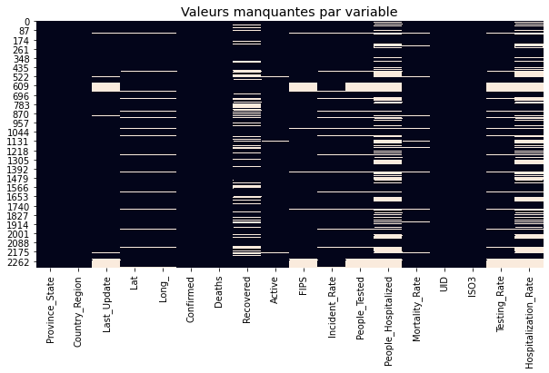

```python
plt.figure(figsize=(10,5))
sns.heatmap(df.isna(), cbar=False)
plt.title(u'Valeurs manquantes par variable', size = 'x-large')
```

# Exploration des données

Dans cette partie on va s'intéresser au nombre de cas confirmés, de morts et cas actifs dans quelques états américains. Le choix de ces états se faisant sur un critère d'indice de richesse par habitant. Cela nous permet d'avoir deux considérés comme riches (Connecticut et Maryland) et deux autres moins riches (Montana et Arkansas).

Les chiffres utilisés pour comparer puis choisir les états sont tirés de : https://fr.wikipedia.org/wiki/Liste_des_lieux_les_plus_riches_aux_%C3%89tats-Unis

Nous avions également trouvé intéssant d'étudier la propagation du virus au sein des différents groupes ethniques présents aux états-unis. Cela n'est toute fois pas possible avec nos données actuelles puisque les groupes minoritaires ne sont pas présents dans des états particuliers. Il nous faudrait donc pour cela des données plus précises par état.

## Etude selon la richesse

Pour cette première partie on prendra comme état riche le Maryland et le Connecticut, puis comme étant pauvre le Montana et l'Arkansas. Cette selection a pour but de visualiser le clivage en terme de décès selon la richesse de l'état.

### Connecticut

On crée un dataframe avec uniquement l'état du Connecticut.

```python
df_c = data[data['Province_State']=='Connecticut']
```

#### Evolution des cas

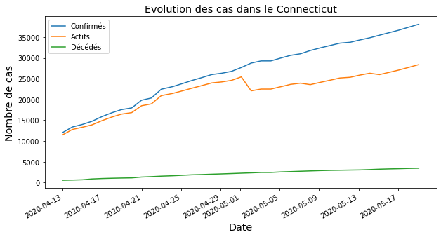

```python
df_c['Confirmed'].plot(figsize=(10,5), label='Confirmés')
df_c['Active'].plot(label='Actifs')
df_c['Deaths'].plot(label = 'Décédés')
plt.legend()
plt.xlabel(u'Date', size = 'x-large')
plt.ylabel(u'Nombre de cas', size = 'x-large')
plt.title(u'Evolution des cas dans le Connecticut', size = 'x-large')
```

##### Remarques :

Il en ressort de cette première analyse qu'à partir du 13 avril 2020, le nombre de cas confirmés était déjà de l'ordre des 12.000 personnes. Le nombre de cas actifs était assez proche de celui des cas confirmés, tout en restant légèrement plus petit. A partir du 01 mai, on note une baisse des cas actifs, lorsqu'au même moment, la courbe des personnes décédée suit une ascension quasi linéaire. On en déduit donc qu'à ce moment, le nombre de personne guéries a considérablement augmenté. On peut emettre l'hypothèse que le nombre de personnes guéries aurait augmenté grâce à un nombre de tests effectués de plus en plus grand.

#### Cas confirmés et personnes testées

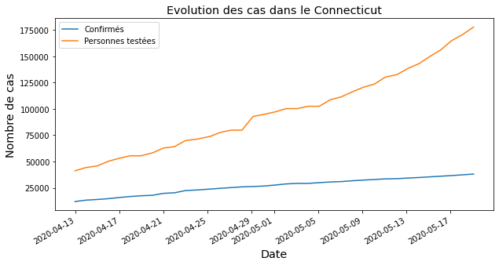

```python
df_c['Confirmed'].plot(figsize=(10,5), label='Confirmés')
df_c['People_Tested'].plot(label='Personnes testées')
plt.legend()
plt.xlabel(u'Date', size = 'x-large')
plt.ylabel(u'Nombre de cas', size = 'x-large')
plt.title(u'Evolution des cas dans le Connecticut', size = 'x-large')
```

##### Remarques :

L'hypothèse émise précédemment n'est donc pas fondée puique le nombre de tests effectués dans cet état était déjà au dessus du nombre de cas confirmés à partir du 13 avril.

### Maryland

```python
df_m = data[data['Province_State']=='Maryland']
```

#### Evolution des cas

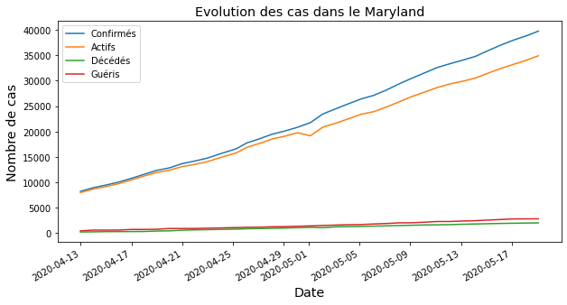

```python
df_m['Confirmed'].plot(figsize=(10,5), label='Confirmés')
df_m['Active'].plot(label='Actifs')
df_m['Deaths'].plot(label = 'Décédés')
df_m['Recovered'].plot(label='Guéris')
plt.legend()
plt.xlabel(u'Date', size = 'x-large')
plt.ylabel(u'Nombre de cas', size = 'x-large')
plt.title(u'Evolution des cas dans le Maryland', size = 'x-large')
```

##### Remarques :

Le graphique ci-dessus suit quasiment la même évolution que celui sur le Connecticut. En effet, à partir du 13 avril 2020, le nombre de cas confirmés est supérieur au nombre de cas actifs et à partir du 01 mai, on note aussi baisse du nombre de cas actifs, qui se poursuit par une différence plus marquée avec le nombre de cas confirmés. On voit que cela est dû à une légère augmentation du nombre de personnes guéries. On peut se demander comment évolue globalement le nombre de morts et le nombre de personnes hospitalisées.

### Ratio Hospitalisation/mortalité

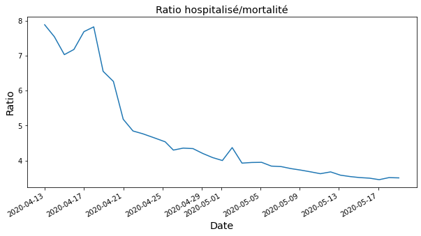

```python
taux = df_m['Hospitalization_Rate']/ df_m['Mortality_Rate']
taux.plot(figsize=(10,5))


plt.xlabel(u'Date', size = 'x-large')
plt.ylabel(u'Ratio', size = 'x-large')
plt.title(u'Ratio hospitalisé/mortalité', size = 'x-large')
```

### Arkansas

```python
df_a = data[data['Province_State'] == 'Arkansas']
```

#### Evolution des cas

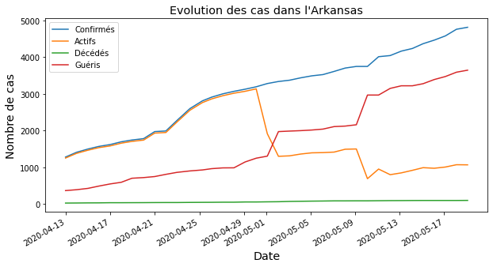

```python
df_a['Confirmed'].plot(figsize=(10,5), label='Confirmés')
df_a['Active'].plot(label='Actifs')
df_a['Deaths'].plot(label = 'Décédés')
df_a['Recovered'].plot(label='Guéris')
plt.legend()
plt.xlabel(u'Date', size = 'x-large')
plt.ylabel(u'Nombre de cas', size = 'x-large')
plt.title(u'Evolution des cas dans l\'Arkansas', size = 'x-large')
```

##### Remarques :

On voit sur ce graphique que le nombre de cas actifs baisse de manière significative à partir du 01 mai 2020 pendant qu'au même moment les cas guéris suivent une forte croissance. Le nombre de morts suit une légère croissance, on peut émettre l'hypothèse que cet état (moins riche) a une meilleure gestion de l'épidémie que les deux états plus riches qu'on a vu précédemment.

### Montana

```python
df_mt  = data[data['Province_State'] == 'Montana']
```

#### Evolution des cas

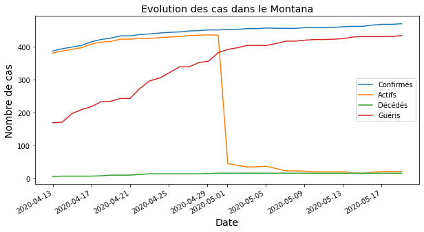

```python
df_mt['Confirmed'].plot(figsize=(10,5), label='Confirmés')
df_mt['Active'].plot(label='Actifs')
df_mt['Deaths'].plot(label = 'Décédés')
df_mt['Recovered'].plot(label='Guéris')
plt.legend()
plt.xlabel(u'Date', size = 'x-large')
plt.ylabel(u'Nombre de cas', size = 'x-large')
plt.title(u'Evolution des cas dans le Montana', size = 'x-large')
```

##### Remarques :

Du graphique ci-dessus, on en déduit que la Montana suit globalement les mêmes trajectoires d'évolution que l'Arkansas. La date du 01 mai 2020 est donc un point marquant dans le processus d'amélioration de la gestion de l'épidémie dans le pays et plus particulièrement dans les états moins riches étudiés. On peut se demander si cette évolution est généralisée à l'ensemble des états moins riches du pays et quels autres éléments entrent en jeu dans la proportion de personnes décédées par état.

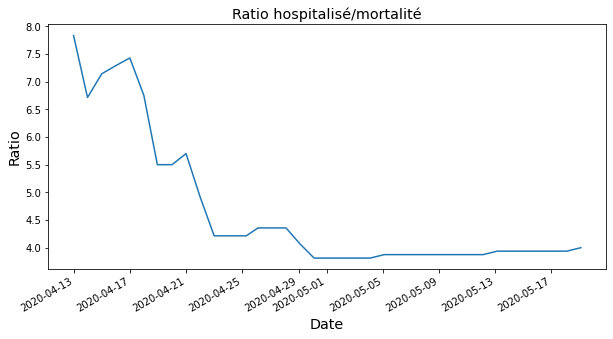

```python
taux = df_mt['Hospitalization_Rate']/ df_mt['Mortality_Rate']
taux.plot(figsize=(10,5))


plt.xlabel(u'Date', size = 'x-large')
plt.ylabel(u'Ratio', size = 'x-large')
plt.title(u'Ratio hospitalisé/mortalité', size = 'x-large')
```

## Répartion des cas selon l'état

Afin d'établir une estimation de la mortalité dans chacun des états de notre étude, on va se pencher sur leur taux de mortalité. Néanmoins ces chiffres pourraient être liés à d'autres variables, c'est pourquoi nous vérifierons les corrélations dans la suite afin de confirmer ou non nos hypothèses.

### Etude du taux de mortalité

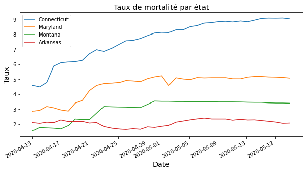

```python
df_c['Mortality_Rate'].plot(figsize=(10,5), label='Connecticut')
df_m['Mortality_Rate'].plot(figsize=(10,5), label='Maryland')
df_mt['Mortality_Rate'].plot(figsize=(10,5), label='Montana')
df_a['Mortality_Rate'].plot(figsize=(10,5), label='Arkansas')

plt.legend()
plt.xlabel(u'Date', size = 'x-large')
plt.ylabel(u'Taux', size = 'x-large')
plt.title(u'Taux de mortalité par état', size = 'x-large')
```

#### Remarques :

# Variables importantes

Nous avons précédemment poser l'hypothèse que le taux de mortalité serait lié à une ou d'autres variables. Dans cette partie nous allons dans un premier temps étudier l'importance des variables via une ACP, et par la suite nous verrons les corrélations entre elles. Nous ne garderons que les variables quantitatives afin d'étudier leurs dépendance.

```python
df1 = df.copy()
df1 = df1.drop(columns=['Province_State','Country_Region','Last_Update','Lat','Long_','FIPS','UID','ISO3'])
```

## Normalisation des données

On normalise nos données afin de réaliser une ACP et en déduire les variables les plus importantes. Cela nécessite qu'on ait des données n'ayant pas de valeurs manquantes, ce qui explique le dropna().

```python
df1 = df1.dropna(axis=0)
sc = StandardScaler()
df1 = sc.fit_transform(df1)
```

### Analyse de Composantes Principales

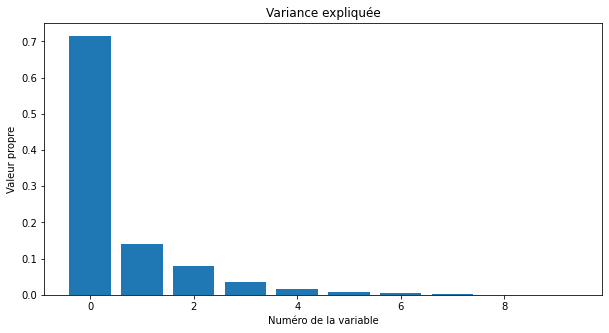

```python
acp = PCA()
df1 = acp.fit_transform(df1)

plt.figure(figsize=(10,5))
plt.bar(np.arange(len(acp.explained_variance_ratio_)),
        acp.explained_variance_ratio_)
plt.title(u"Variance expliquée")
plt.xlabel("Numéro de la variable")
plt.ylabel('Valeur propre')
```

### Analyse des corrélations

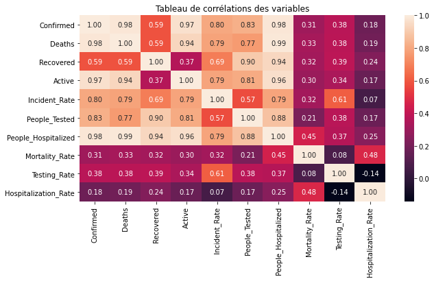

```python
df2 = df.copy()
plt.figure(figsize=(10,5))
sns.heatmap(df2[['Confirmed', 'Deaths', 'Recovered', 'Active','Incident_Rate','People_Tested','People_Hospitalized','Mortality_Rate','Testing_Rate','Hospitalization_Rate']].corr(),annot=True, fmt=".2f")
plt.title('Tableau de corrélations des variables')
plt.show()
```

#### Remarques :

# Cartographie des données

Pour dessiner la structure de notre carte nous importons depuis un lien GitHub, un fichier GeoJson contenant les coordonnées géograhiques des états-unis. Cela nous permet de délimiter chaque état et donc d'y représenter de façon cohérente les données associées.

Lien GitHub : https://raw.githubusercontent.com/python-visualization/folium/master/examples/data/search_states.json

```python
with urlopen('https://raw.githubusercontent.com/python-visualization/folium/master/examples/data/search_states.json') as response:
    etat = json.load(response)
```

## Colonnes importantes

On garde que les colonnes relatives aux décès et états du pays. Variables qui seront représentées sur notre carte

```python
data = data.drop(columns=['FIPS','UID','ISO3','Testing_Rate','Hospitalization_Rate','Mortality_Rate'])
data = data[data['Country_Region']=='US']
```

## Gestion des coordonnées

On récupère dans cette partie les coordonnées géoraphiques des états.

```python
df_map = data.drop(columns=['Confirmed','Recovered','Active','Incident_Rate','People_Tested','People_Hospitalized'])
df_map = df_map[["Province_State","Lat","Long_"]]
df_map.dropna(axis=0)
df_map.head()
```

| Last_Update | Province_State | Lat | Long_ |
| --- | --- | --- | --- |
| 2020-04-30 02:32:31 | Alabama | 32.3182 | -86.9023 |
| 2020-04-30 02:32:31 | Alaska | 61.3707 | -152.4044 |
| 2020-04-30 02:32:31 | American Samoa | -14.2710 | -170.1320 |
| 2020-04-30 02:32:31 | Arizona | 33.7298 | -111.4312 |
| 2020-04-30 02:32:31 | Arkansas | 34.9697 | -92.3731 |

## Morts par état

On récupère dans cette partie le nombre de morts total par état, afin de les représenter sur la carte. Etant donné les grandes disparités entre états en terme de nombre de morts, nous avons fait le choix de les tranformer en utilisant une échelle logarithmique. Cela consiste au calcul de chacune de nos données en logarithme de base 10. En effet cela nous permet d'avoir une répartition homogène de nos données, ce qui permet d'adapter les écarts tout en concervant des distances équivalentes.

### Compte par état

```python
df_mort_etat = data.groupby('Province_State').sum()
mort_etat = df_mort_etat['Deaths']
```

## Exportation de données

On exporte ensuite les données dans un fichier afin d'y faire les opérations de conversions en valeurs logarithmiques. On réimporte ensuite le fichier convertie pour l'insérer dans la carte.

Afin de visualiser la comparaison entre le nombre de morts par état et le taux de chômage, nous avons rajouté à notre fichier les données relatives aux taux de chômmage en avril 2020 des états américains.

```python
mort_etat.to_csv("Donne_carte.csv", sep=";")
```

```python
donne_mort = pd.read_csv("Donne_cartes.csv",sep=",")
```

## Construction de la carte

Nous créons une variable carte prenant en paramètres les coordonnées géographiques des états-unis et initialisant un zoom sur la carte. Ensuite vient la création de le carte de type 'Choropleth', qui permet de mieux visualiser les répartitions de morts avec des dégradés de couleurs adaptés à chaque état.

```python
m = folium.Map(location=[37, -102], zoom_start=4)

folium.Choropleth(
 geo_data=etat,
 name='Mortalite',
 data=donne_mort,
 columns=['Province_State', 'Ratio'],
 key_on='feature.properties.name',
 fill_opacity=0.7,
 line_opacity=0.2,
 fill_color='YlOrRd',
 legend_name='Repartition de la mortalite',
).add_to(m)

folium.Choropleth(
 geo_data=etat,
 name='Chomage',
 data=donne_mort,
 columns=['Province_State', 'Chomage'],
 key_on='feature.properties.name',
 fill_opacity=0.7,
 line_opacity=0.2,
 fill_color='YlGn',
 show = False,
 legend_name='Taux de chomage en avril 2020',
).add_to(m)

folium.LayerControl(collapsed=True).add_to(m)


m
```

[interactive chart not shown]

## Commentaires :

Par la suite, lorsqu'on regarde plus attentivement les états ayant un fort taux de mortalité dû au Covid19, et qu'on les compare avec ceux ayant les taux de chômage les plus élevés, on se rend compte que certains états sont redondants. Cela laisse donc à pense que le nombre de morts dû au Covid19 évoluerait de manière proportionnelle au taux de chomage par état. Et puisque les états les plus riches sont ceux ayant les taux de chomage les plus élevés, alors ce sont les mêmes qui ont le plus de morts.

# Conclusion

L'analyse statistique de ce jeu de données nous a permit de mettre en évidence des disparités de certains états américains face à l'épidémie de Covid19. En effet nous avons pour cela prit en compte quatre états en fonction de leur richesse, deux parmi les plus riches et les deux autres parmi les moins riches. Il en est sorti que les états moins riches avaient de meilleurs résultats dans la gestion de l'épidémie que les plus riches, notamment grâce à des taux de mortalité moins élevés.

Néanmoins cela peut être dû à la densité d'habitants qui est plus élevée dans les états riches, ce qui favorise la propagation de l'épidémie. Nous observons le même phénomène avec les régions françaises, où on voit que les lieux les plus touchés sont les grandes villes. De plus en comparant les états les plus touchés en terme de morts et ceux ayant un taux de chômage élevés, il en ressort que le taux de chômage joue aussi un rôle dans le nombre de morts dûes au Covid19 dans un état.

Dans la suite de notre étude, nous sélectionnerons les variables utiles dans la construction de notre modèle de prédiction du nombre de morts.

# Finalisation de l'étude

## Explication du choix des variables à garder

Premièrement nous avons enlever toutes les variables non importantes trouvées dans l'étude de corrélation et l'ACP. Il s'agit des variables de taux d'hospitalisation, mortalité et de tests effectués. Ensuite il a été préférable de ne pas garder les numéro d'indentifiction des personnes par les agences nationales américaines. De plus puisqu'il s'agit des états-unis, nous avons enlevé le pays et aussi les coordonnées géographique des états.

Les données commentées ci-dessus font référence à celles que nous allons utiliser dans le modèle de prédiction, nous avons sauvegardé d'autres données en y conservant les latitudes et longitudes pour la création d'une carte intéractive.

#### Auteur de l'étude :

Daniel ATANGANA en collaboration avec

- BUISSON-CHAVOT Julien
- CHATRY Roxane
- GORRICHON Nahia
- VIRGAUX Pierre

#### Date : 27/05/2020

#### Contexte : Etude statistique du Covid19 au Etats-Unis